# MarcosUeta_MT_Project_LearnerNotebook_FullCode_revD

### Test set final performance

```python
# Calculating different metrics on the test set
gbm_grid_test = model_performance_classification_sklearn(XGB_tuned_un, X_test, y_test)
print("XB Boosting Test Performance (undersampled):")
gbm_grid_test
```

```
XB Boosting Test Performance (undersampled):
```

|  | Accuracy | Recall | Precision | F1 |
| --- | --- | --- | --- | --- |
| 0 | 0.868 | 0.887 | 0.285 | 0.432 |

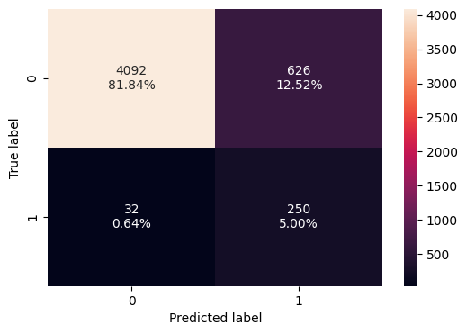

```python
# creating confusion matrix
confusion_matrix_sklearn(XGB_tuned_un, X_test, y_test)
```

#### Feature Importance

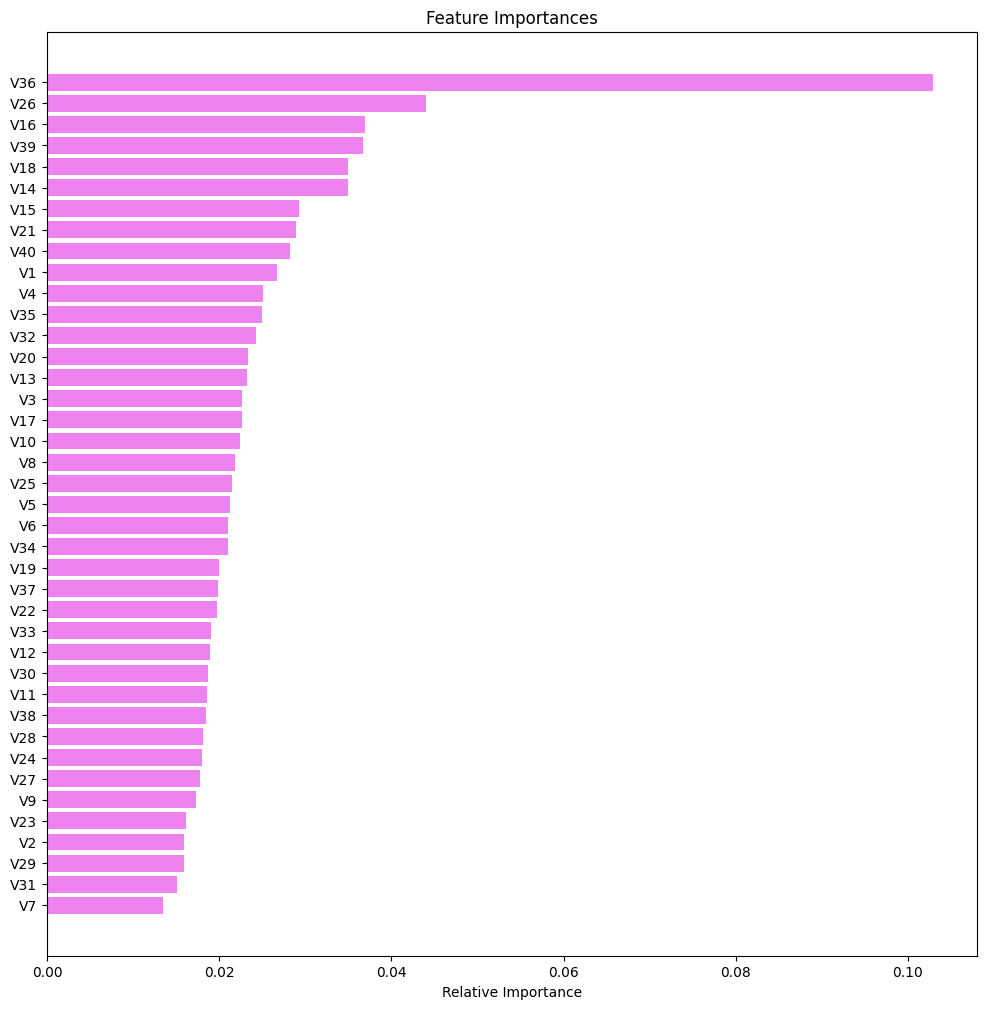

```python
feature_names = X_train_un.columns
importances = XGB_tuned_un.feature_importances_
indices = np.argsort(importances)

plt.figure(figsize=(12, 12))
plt.title("Feature Importances")
plt.barh(range(len(indices)), importances[indices], color="violet", align="center")
plt.yticks(range(len(indices)), [feature_names[i] for i in indices])
plt.xlabel("Relative Importance")
plt.show()
```

- Feature V36 is the most importance feature among 40 features.

#### V36 feature analysis

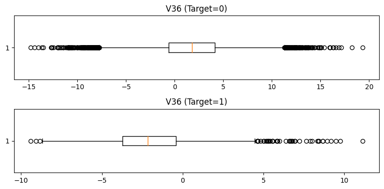

```python
plt.figure(figsize=(8, 4))
plt.subplot(2, 1, 1)
plt.boxplot(df_total[df_total['Target'] == 0]['V36'], vert=False)
plt.title('V36 (Target=0)')
plt.subplot(2, 1, 2)
plt.boxplot(df_total[df_total['Target'] == 1]['V36'], vert=False)
plt.title('V36 (Target=1)')
plt.tight_layout()
plt.show()
```

- The V36 boxplot suggested that a probability of fail is increased when values are below than 0. However, there is no clear conclusion of V36 itself. The failure happened with a combination of other features values.

## Pipelines to build the final model

```python
# creating a list of numerical variables
numerical_features = [f"V{i}" for i in range(1, 41)]

# creating a transformer for numerical variables, which will apply simple imputer on the numerical variables
numeric_transformer = Pipeline(steps=[("imputer", SimpleImputer(strategy="median"))])

# combining categorical transformer and numerical transformer using a column transformer

preprocessor = ColumnTransformer(
    transformers=[
        ("num", numeric_transformer, numerical_features),
    ],
    remainder="passthrough",
)
# remainder = "passthrough" has been used, it will allow variables that are present in original data
# but not in "numerical_columns" and "categorical_columns" to pass through the column transformer without any changes
```

```python
# to get best parameters from XGBoosting
# defining model
Model = XGBClassifier(random_state=1)

# Parameter grid to pass in RandomSearchCV
param_grid={ 'n_estimators': [150, 200, 250], 'scale_pos_weight': [5,10], 'learning_rate': [0.1,0.2], 'gamma': [0,3,5], 'subsample': [0.8,0.9] }

#Calling RandomizedSearchCV
randomized_cv = RandomizedSearchCV(estimator=Model, param_distributions=param_grid, n_iter=10, n_jobs = -1, scoring=scorer, cv=5, random_state=1)

#Fitting parameters in RandomizedSearchCV
randomized_cv.fit(X_train_un,y_train_un)

print("Best parameters are {} with CV score={}:" .format(randomized_cv.best_params_,randomized_cv.best_score_))
```

```
Best parameters are {'subsample': 0.9, 'scale_pos_weight': 10, 'n_estimators': 250, 'learning_rate': 0.1, 'gamma': 5} with CV score=0.9266503138301709:
```

```python
# Creating a new pipeline with best parameters
Final_pipeline_model = Pipeline(
    steps=[
        ("pre", preprocessor),
        (
            "XGBoosting",
            XGBClassifier(
                subsample=0.9,
                scale_pos_weight=10,
                n_estimators=250,
                learning_rate=0.1,
                gamma=5
            ),
        ),
    ]
)

# Fit the model on training data
Final_pipeline_model.fit(X_train_un, y_train_un)
```

```
Pipeline(steps=[('pre',
                 ColumnTransformer(remainder='passthrough',
                                   transformers=[('num',
                                                  Pipeline(steps=[('imputer',
                                                                   SimpleImputer(strategy='median'))]),
                                                  ['V1', 'V2', 'V3', 'V4', 'V5',
                                                   'V6', 'V7', 'V8', 'V9',
                                                   'V10', 'V11', 'V12', 'V13',
                                                   'V14', 'V15', 'V16', 'V17',
                                                   'V18', 'V19', 'V20', 'V21',
                                                   'V22', 'V23', 'V24', 'V25',
                                                   'V26', 'V27', 'V28', 'V29',
                                                   'V30', ...])])),
                ('XGBoosting',
                 XGBCla...
                               feature_types=None, gamma=5, gpu_id=None,
                               grow_policy=None, importance_type=None,
                               interaction_constraints=None, learning_rate=0.1,
                               max_bin=None, max_cat_threshold=None,
                               max_cat_to_onehot=None, max_delta_step=None,
                               max_depth=None, max_leaves=None,
                               min_child_weight=None, missing=nan,
                               monotone_constraints=None, n_estimators=250,
                               n_jobs=None, num_parallel_tree=None,
                               predictor=None, random_state=None, ...))])
```

```python
# Calculating different metrics on test set
Test_Score = model_performance_classification_sklearn(Final_pipeline_model, X_test, y_test)
print("Final Model performance on Test Dataset:")
Test_Score
```

```
Final Model performance on Test Dataset:
```

|  | Accuracy | Recall | Precision | F1 |
| --- | --- | --- | --- | --- |
| 0 | 0.868 | 0.887 | 0.285 | 0.432 |

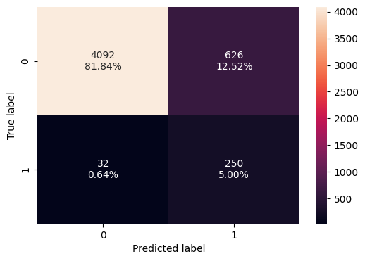

```python
# creating confusion matrix
confusion_matrix_sklearn(Final_pipeline_model, X_test, y_test)
```

# Business Insights and Conclusions

Key Model Performance Metrics:

- Test Recall: 88.7% (Primary Objective)
  - High recall indicates good detection of failures
    - It makes possible to avoid replacement or repairing costs.
- Test Precision: 28.5%
  - Low precision implies potential false positives (FP), which are acceptable due to cost considerations.
    - Inspection costs are lower than replacement or repair costs.

Business Insights:

- Limited scope for in-depth business insights based on these ciphers alone, once all features are encrypted sensor data related to various environmental factors (temperature, humidity, wind speed, etc.) and additional features related to various parts of the wind turbine (gearbox, tower, blades, break, etc.).
- Special attention for feature V36. It is the most crucial among the 40 features, followed by V26, V16, and V39.
- There is no clear indication of a specific range of failure values in any of the features. This means that failure is results through a combination of features, not by any one individually.
- In the aspect of cost reduction, we have identified sensors (features) that can be turned off as they exhibit high correlation with other sensors. Please see section "Plotting all the features at one go".
  - 8 features with high correlation (> 0.75).
  - 7 features with inverse high correlation (<-0.75).